# Fire Duration Prediction

## Adding new variables

We add new variables related to ndmi - Vegetation Moisture Index cause_description - Human-readable cause of fire fuel_type - Categorized burnable material

```r
cov_columns_new <- c("min_temp","max_temp","avg_temp","avg_windspeed","avg_precipitation", "elevation", "landcover", "aspect", "slope", "ndvi", "avg_pdsi", "avg_spi30d", "ndmi","fuel_type", "cause_description")
```

```r
train_XY=train_data |> select(c(Fire_Duration, all_of(cov_columns_new)))
```

### Linear Model Fit

```r
fit_rel <- lm(Fire_Duration ~ .,data = train_XY)
summary(fit_rel)
```

```
##
## Call:
## lm(formula = Fire_Duration ~ ., data = train_XY)
##
## Residuals:
##      Min       1Q   Median       3Q      Max
## -110.962  -22.090   -3.317   17.349  188.459
##
## Coefficients:
##                                                   Estimate Std. Error t value
## (Intercept)                                     -143.85637  154.43532  -0.931
## min_temp                                          -9.55861    0.70184 -13.619
## max_temp                                           5.30515    0.76207   6.961
## avg_temp                                           6.73754    1.22666   5.493
## avg_windspeed                                      3.53871    1.17614   3.009
## avg_precipitation                                189.14354   65.26804   2.898
## elevation                                         -0.01358    0.00537  -2.528
## landcover                                         -0.73791    1.82324  -0.405
## aspect                                            -0.01426    0.01987  -0.718
## slope                                             -0.07306    0.24920  -0.293
## ndvi                                               1.31744    8.18185   0.161
## avg_pdsi                                          -4.67132    1.33999  -3.486
## avg_spi30d                                        12.80105    3.17602   4.031
## ndmi                                               3.39995   25.86648   0.131
## fuel_typeForest                                  -13.70039   74.21352  -0.185
## fuel_typeGrassland                                14.09700   24.15371   0.584
## fuel_typeShrubland                                -0.20123   56.37193  -0.004
## fuel_typeUrban                                   -32.34513  110.93249  -0.292
## fuel_typeWetland                                  31.61473   31.09261   1.017
## cause_descriptionEquipment/vehicles              -19.76897   14.50727  -1.363
## cause_descriptionFire Play (minor)                -1.60514   26.36934  -0.061
## cause_descriptionFireworks                       -16.02896   14.69381  -1.091
## cause_descriptionIncendiary (unlawful)             6.14797   15.16743   0.405
## cause_descriptionMiscellaneous/other             -11.82446   14.12489  -0.837
## cause_descriptionNatural                         -18.87717   14.62167  -1.291
## cause_descriptionPower generation/transmission    -4.25597   15.47133  -0.275
## cause_descriptionRecreation/cultural activities   13.81344   18.29705   0.755
## cause_descriptionUnknown                         202.91260   42.95699   4.724
## cause_descriptionUnknown (Human)                  -9.23389   13.84074  -0.667
##                                                 Pr(>|t|)
```

[output cut: 21 more lines]

```
## cause_descriptionFireworks                      0.276011
## cause_descriptionIncendiary (unlawful)          0.685451
## cause_descriptionMiscellaneous/other            0.403033
## cause_descriptionNatural                        0.197460
## cause_descriptionPower generation/transmission  0.783396
## cause_descriptionRecreation/cultural activities 0.450735
## cause_descriptionUnknown                        3.25e-06 ***
## cause_descriptionUnknown (Human)                0.505072
## ---
## Signif. codes:  0 '***' 0.001 '**' 0.01 '*' 0.05 '.' 0.1 ' ' 1
##
## Residual standard error: 38.73 on 387 degrees of freedom
##   (1 observation deleted due to missingness)
## Multiple R-squared:  0.7017, Adjusted R-squared:  0.6801
## F-statistic: 32.52 on 28 and 387 DF,  p-value: < 2.2e-16
```

```r
vif(fit_rel)
```

```
##                         GVIF Df GVIF^(1/(2*Df))
## min_temp            4.280130  1        2.068847
## max_temp            4.751095  1        2.179701
## avg_temp            7.912876  1        2.812984
## avg_windspeed       1.276734  1        1.129927
## avg_precipitation   2.245148  1        1.498382
## elevation           2.464427  1        1.569849
## landcover         320.997839  1       17.916413
## aspect              1.092386  1        1.045173
## slope               1.379768  1        1.174635
## ndvi                1.454354  1        1.205966
## avg_pdsi            2.358869  1        1.535861
## avg_spi30d          2.245611  1        1.498536
## ndmi                1.433391  1        1.197243
## fuel_type         699.743233  5        1.925280
## cause_description   2.476770 10        1.046392
```

We see that there is very high collinearity in land_cover and fuel_type as they relate to the same identity of vegetation. We remove landcover and only use fuel_type for our variable selection and models from now on as fuel_type is more descriptive.

Also min_temp, max_temp and avg_temp are collinear upto some extent and can be adjusted.

### Only Variables with no collinearity

```r
cov_columns_ind <- c("min_temp","max_temp","avg_temp","avg_windspeed","avg_precipitation", "elevation", "aspect", "slope", "ndvi", "avg_pdsi", "avg_spi30d", "ndmi","fuel_type", "cause_description")
```

### Lasso Fit

```r
y <- data_rel$Fire_Duration
x <- model.matrix(Fire_Duration ~ ., data=data_rel |> select(c(Fire_Duration, all_of(cov_columns_ind))) )

set.seed(12345)
trainIndex <- sample(1:nrow(x), nrow(x)*0.9)

ytrain <- y[trainIndex]
xtrain <- x[trainIndex,1:ncol(x)]
```

#### Variable selection using CV Lasso Model

```r
set.seed(1234)
cv_fit <- cv.glmnet(xtrain, ytrain,alpha=1, nfolds = 5)
```

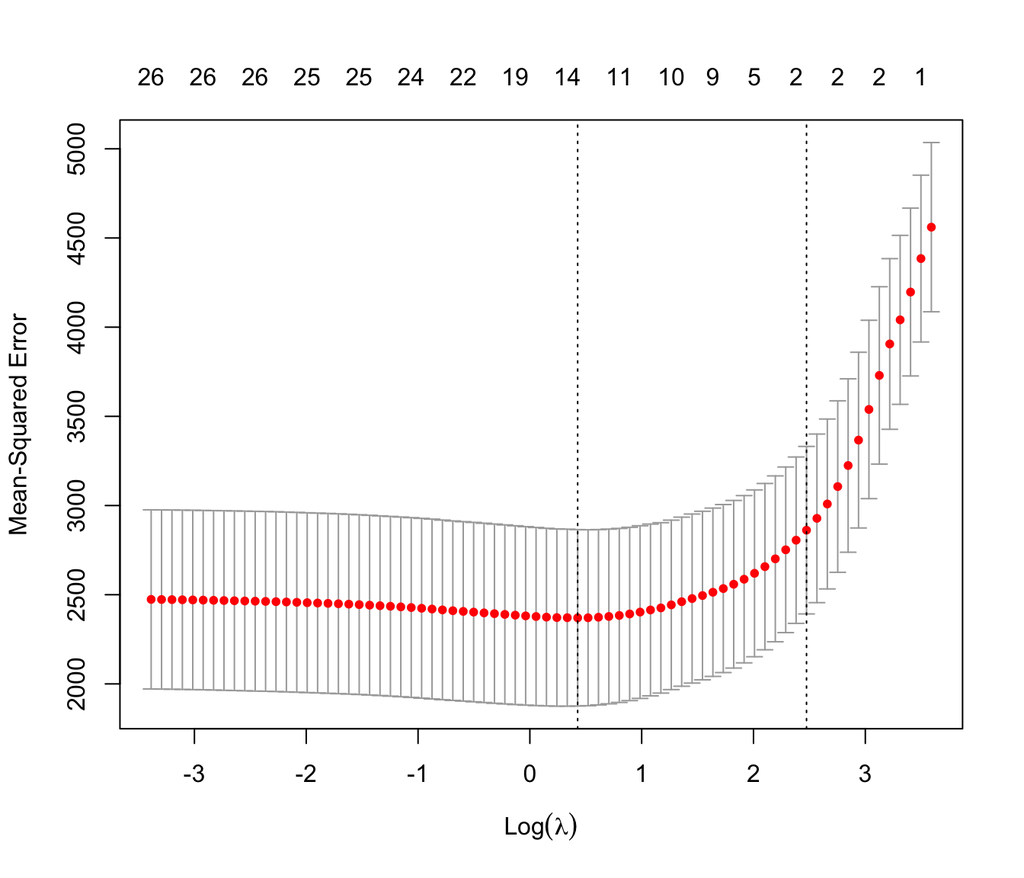

```r
plot(cv_fit)
```

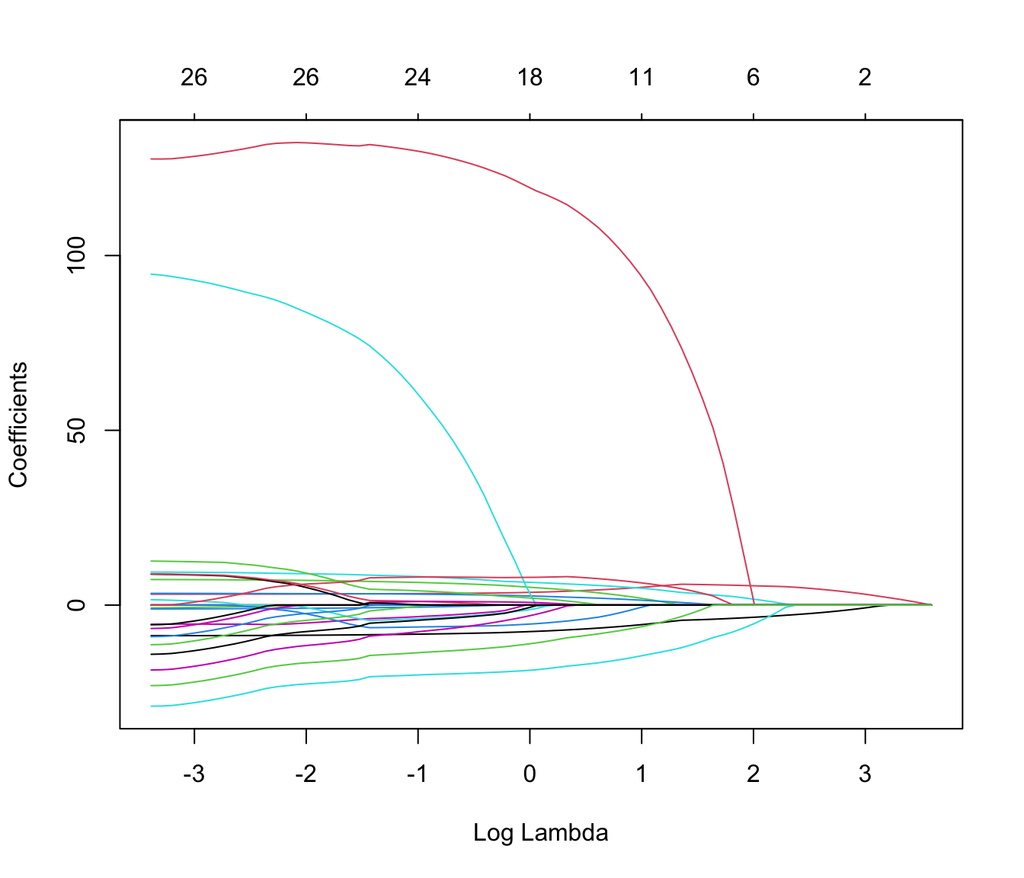

```r
plot(cv_fit$glmnet.fit, xvar = "lambda")
```

We select the variables which are present in the Lasso Model with lowest cross validation error.

```r
coef_min <- coef(cv_fit, s = "lambda.min")
sel_vars_min <- rownames(coef_min)[which(coef_min != 0)][-1]
```

```r
sel_vars_min
```

```
##  [1] "min_temp"                         "max_temp"
##  [3] "avg_temp"                         "avg_windspeed"
##  [5] "elevation"                        "avg_spi30d"
##  [7] "fuel_typeShrubland"               "fuel_typeUrban"
##  [9] "cause_descriptionFireworks"       "cause_descriptionNatural"
## [11] "cause_descriptionUnknown"         "cause_descriptionUnknown (Human)"
```

## Different Fits

We selected the top attributes and now we fit multiple models to increase the R2 and decrease Test MSE.

### Getting the Model Matrix with selected variables only

```r
data_df=data_rel |> select(c(Fire_Duration, all_of(cov_columns_ind)))
data_df <- data_df |> na.omit()
```

```r
y <- data_df$Fire_Duration
x <- model.matrix(Fire_Duration ~ . - 1, data=data_df)

set.seed(1234)
trainIndex <- sample(1:nrow(x), nrow(x)*0.9)

# Train Model Matrix
ytrain <- y[trainIndex]
xtrain <- x[trainIndex,sel_vars_min]
train_df <- as.data.frame(xtrain) |> mutate(Fire_Duration = ytrain)


# Test Model Matrix
ytest <- y[-trainIndex]
xtest <- x[-trainIndex,sel_vars_min]
test_df <- as.data.frame(xtest) |> mutate(Fire_Duration = ytest)
```

```r
# Cleaning the data
train_df <- clean_names(train_df)
test_df <- clean_names(test_df)
```

### Linear Model Fit for selected vars

```r
ffit_lm <- lm(fire_duration ~ ., data = train_df)
summary(ffit_lm)
```

```
##
## Call:
## lm(formula = fire_duration ~ ., data = train_df)
##
## Residuals:
##      Min       1Q   Median       3Q      Max
## -129.100  -22.422   -5.092   17.025  209.831
##
## Coefficients:
##                                   Estimate Std. Error t value Pr(>|t|)
## (Intercept)                     -1.513e+02  2.069e+01  -7.312 1.43e-12 ***
## min_temp                        -9.966e+00  6.923e-01 -14.395  < 2e-16 ***
## max_temp                         4.555e+00  7.399e-01   6.156 1.80e-09 ***
## avg_temp                         6.257e+00  1.122e+00   5.579 4.46e-08 ***
## avg_windspeed                    4.700e+00  1.182e+00   3.975 8.34e-05 ***
## elevation                       -1.829e-02  4.872e-03  -3.754 0.000199 ***
## avg_spi30d                       2.932e+00  2.401e+00   1.221 0.222704
## fuel_type_shrubland              4.184e+00  4.754e+00   0.880 0.379261
## fuel_type_urban                 -3.654e+00  5.496e+00  -0.665 0.506498
## cause_description_fireworks     -6.385e+00  6.988e+00  -0.914 0.361359
## cause_description_natural       -1.481e+01  7.113e+00  -2.083 0.037904 *
## cause_description_unknown        1.947e+02  4.198e+01   4.639 4.75e-06 ***
## cause_description_unknown_human -8.802e-01  4.780e+00  -0.184 0.854005
## ---
## Signif. codes:  0 '***' 0.001 '**' 0.01 '*' 0.05 '.' 0.1 ' ' 1
##
## Residual standard error: 40.24 on 403 degrees of freedom
## Multiple R-squared:  0.6654, Adjusted R-squared:  0.6554
## F-statistic: 66.77 on 12 and 403 DF,  p-value: < 2.2e-16
```

#### Test MSE

```r
pred.test <- predict(ffit_lm, newdata = test_df)
mean((pred.test-ytest)**2)
```

```
## [1] 1323.041
```

#### R2 Value

```r
test_TSS <- sum((test_df$fire_duration - mean(test_df$fire_duration))**2)
test_RSS <- sum((pred.test - test_df$fire_duration)**2)

cat(round(1 - test_RSS/test_TSS,3))
```

```
## 0.701
```

#### Plotting Residual Plot

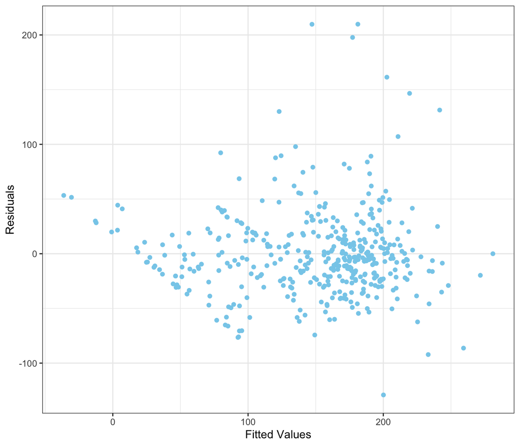

```r
ggplot() +
  geom_point(mapping=aes(x=ffit_lm$fitted.values, y=ffit_lm$residuals), color="skyblue") +
  xlab("Fitted Values")+
  ylab("Residuals")+
  theme_bw()
```

### GAM Model

```r
colnames(train_df)
```

```
##  [1] "min_temp"                        "max_temp"
##  [3] "avg_temp"                        "avg_windspeed"
##  [5] "elevation"                       "avg_spi30d"
##  [7] "fuel_type_shrubland"             "fuel_type_urban"
##  [9] "cause_description_fireworks"     "cause_description_natural"
## [11] "cause_description_unknown"       "cause_description_unknown_human"
## [13] "fire_duration"
```

```r
formula_gam <- as.formula(
  paste("fire_duration ~ s(`max_temp`) + s(`min_temp`) + s(`avg_temp`) + s(`avg_windspeed`)  + s(`elevation`) +
  s(`avg_spi30d`) + `fuel_type_shrubland` + `fuel_type_urban` +
  `cause_description_fireworks` + `cause_description_natural` + `cause_description_unknown` +
  `cause_description_unknown_human` "))

ffit_gam <- gam(formula_gam, data = train_df)
```

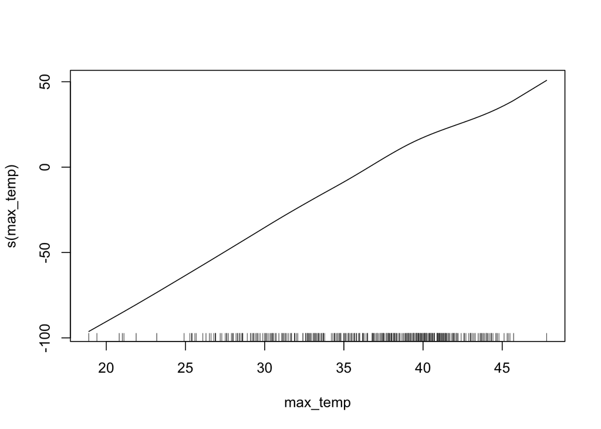

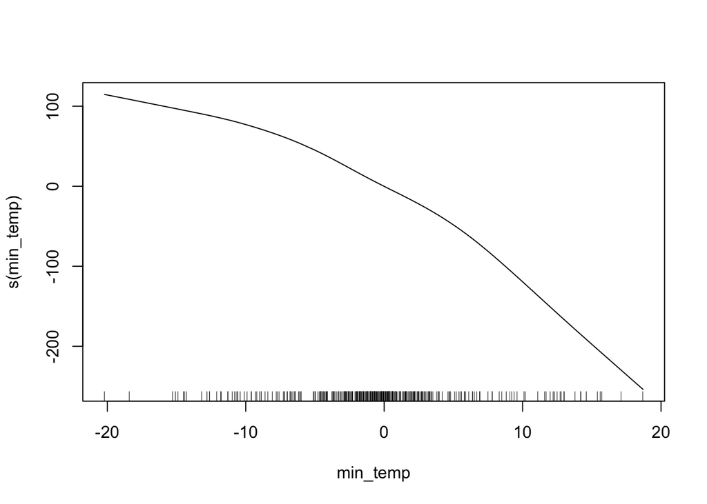

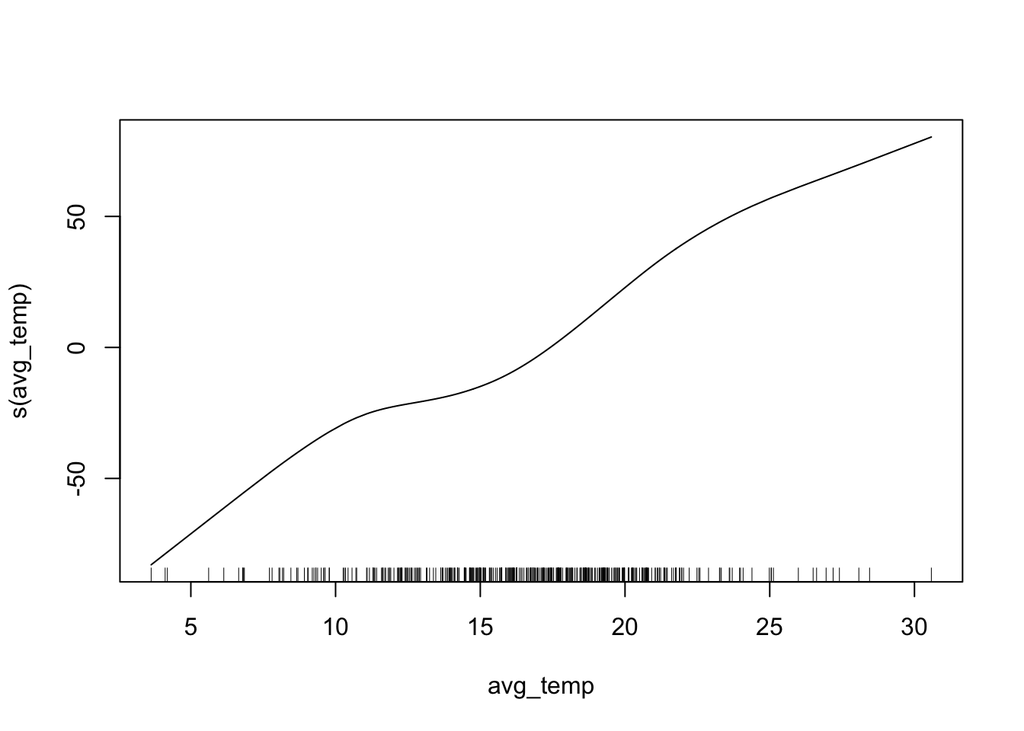

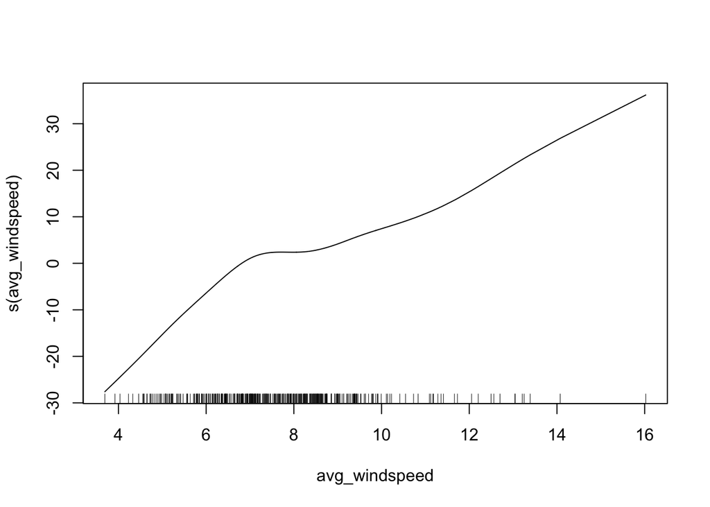

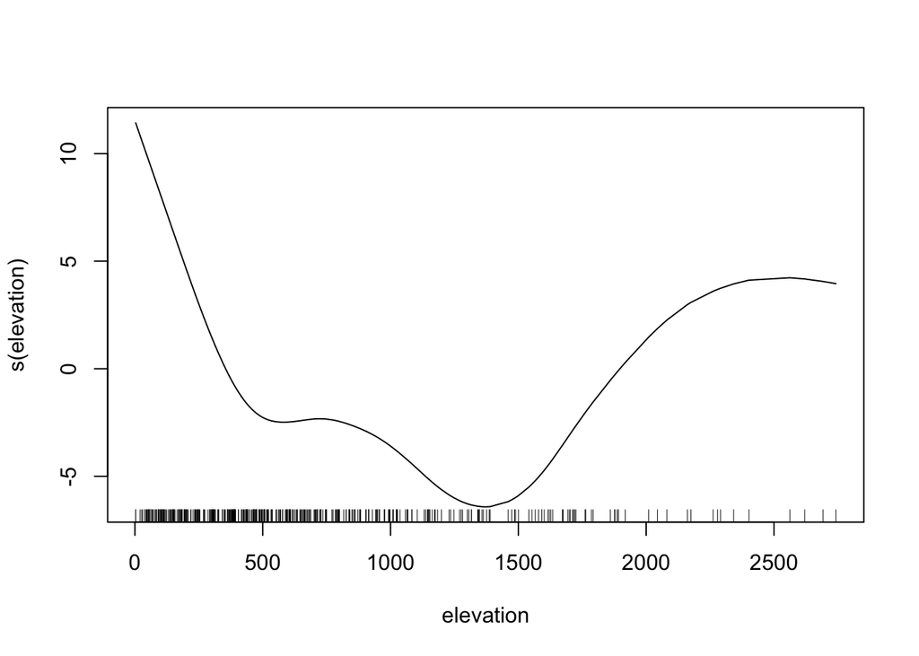

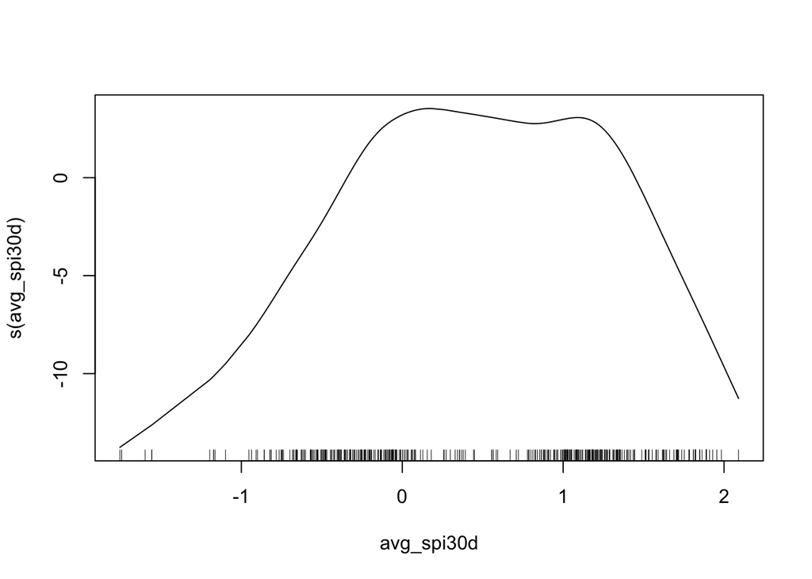

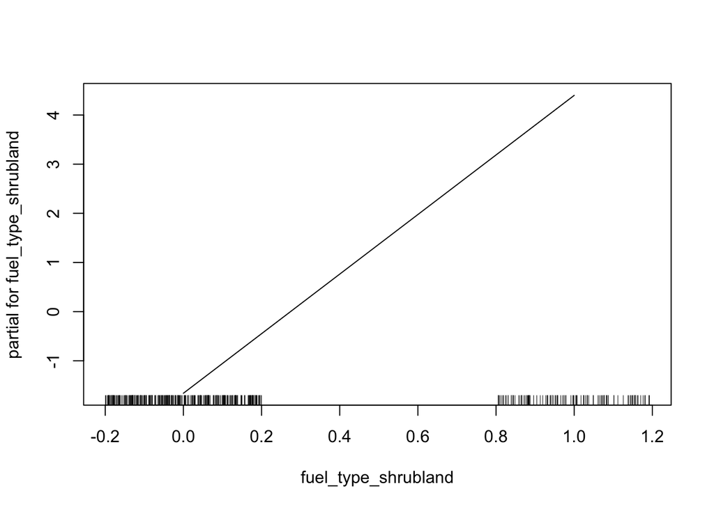

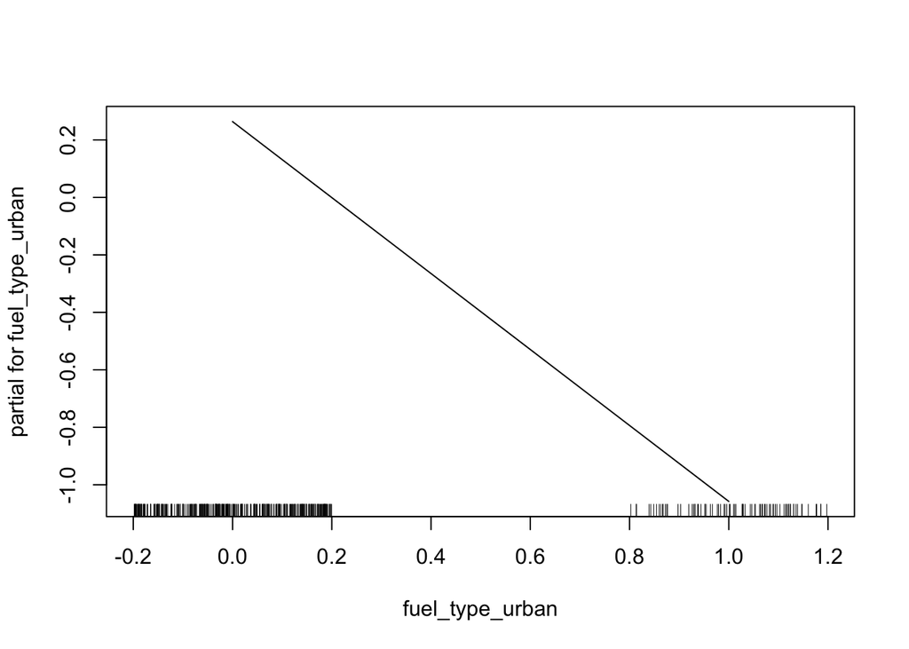

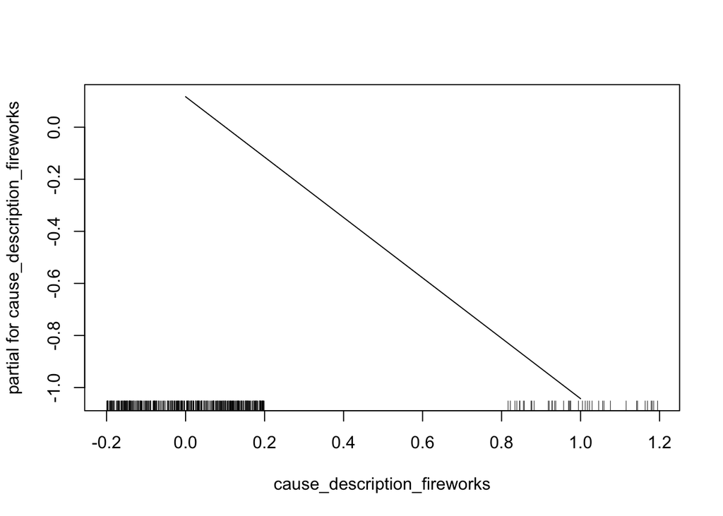

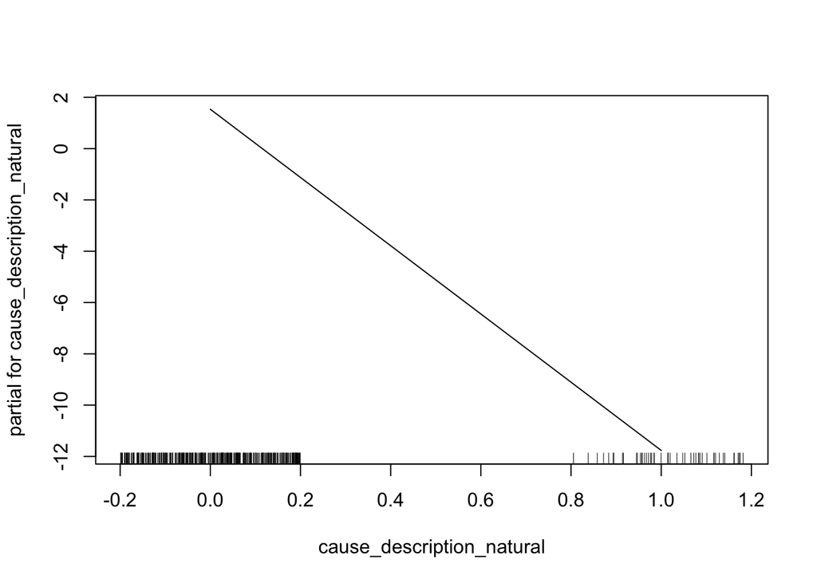

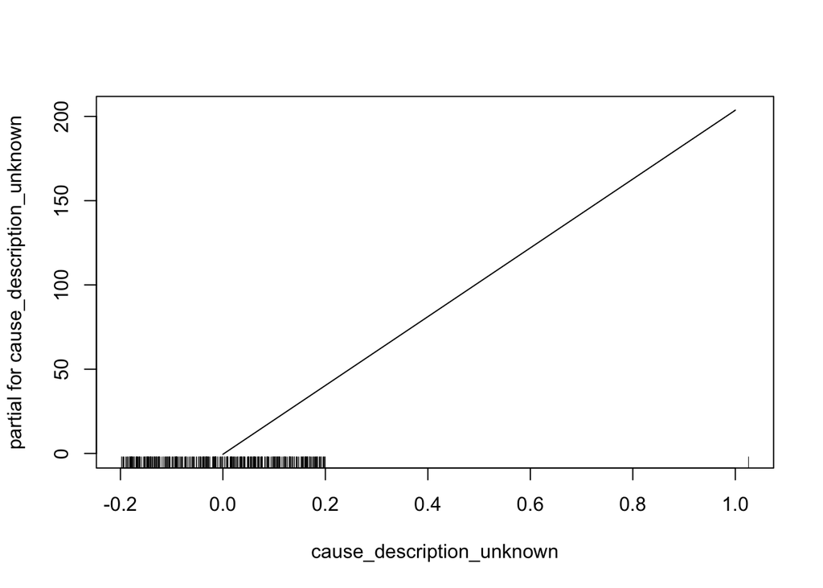

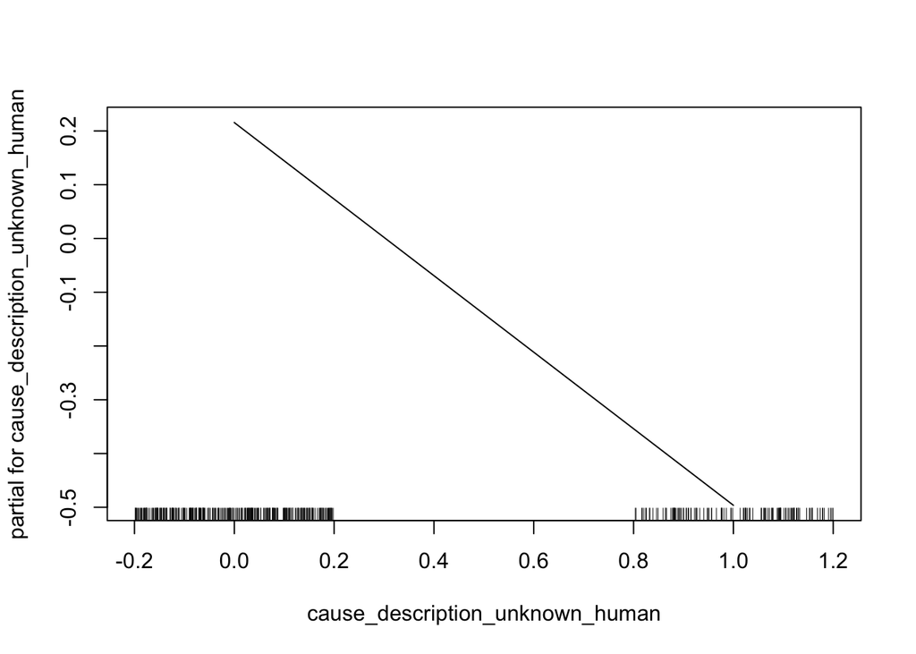

```r
plot(ffit_gam)
```

#### Test MSE

```r
pred.test <- predict(ffit_gam, newdata = test_df)
mean((pred.test-ytest)**2)
```

```
## [1] 1310.229
```

#### R2 Value

```r
test_TSS <- sum((test_df$fire_duration - mean(test_df$fire_duration))**2)
test_RSS <- sum((pred.test - test_df$fire_duration)**2)

cat(round(1 - test_RSS/test_TSS,3))
```

```
## 0.704
```

### Random Forest Regressor

```r
set.seed(123)
rf_model <- randomForest(
  fire_duration ~ .,
  data = train_df,
  ntree = 1000,
  mtry = floor(sqrt(ncol(train_df))),
  importance = TRUE
)

summary(rf_model)
```

```
##                 Length Class  Mode
## call               6   -none- call
## type               1   -none- character
## predicted        416   -none- numeric
## mse             1000   -none- numeric
## rsq             1000   -none- numeric
## oob.times        416   -none- numeric
## importance        24   -none- numeric
## importanceSD      12   -none- numeric
## localImportance    0   -none- NULL
## proximity          0   -none- NULL
## ntree              1   -none- numeric
## mtry               1   -none- numeric
## forest            11   -none- list
## coefs              0   -none- NULL
## y                416   -none- numeric
## test               0   -none- NULL
## inbag              0   -none- NULL
## terms              3   terms  call
```

#### Test MSE

```r
pred.test <- predict(rf_model, newdata = test_df)
mean((pred.test-ytest)**2)
```

```
## [1] 816.9769
```

#### R2 Value

```r
test_TSS <- sum((test_df$fire_duration - mean(test_df$fire_duration))**2)
test_RSS <- sum((pred.test - test_df$fire_duration)**2)

cat(round(1 - test_RSS/test_TSS,3))
```

```
## 0.816
```

### Rpart Model

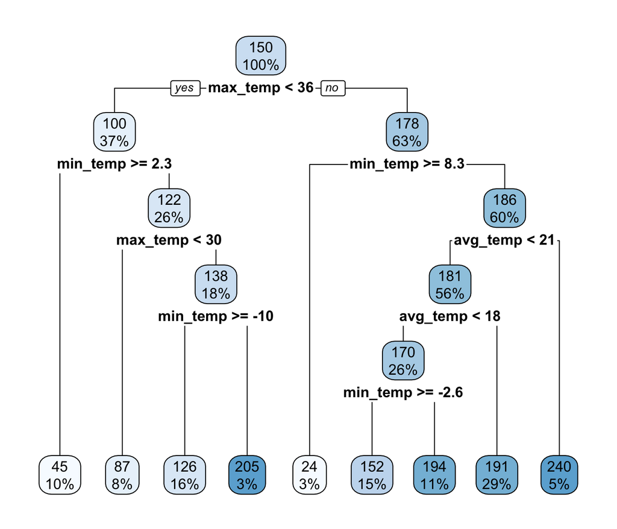

```r
library(rpart)
library(rpart.plot)

# Fit tree
tree_model <- rpart(fire_duration ~ ., data = train_df, method = "anova")

# Plot the tree
rpart.plot(tree_model)
```

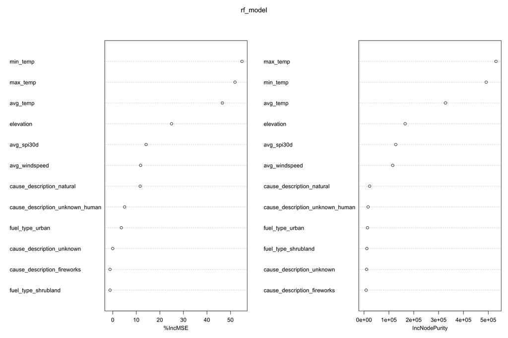

```r
varImpPlot(rf_model)
```